# Exploration of 2016 US Presidential Campaign Contribution Data for the State of New York

Roberto Zanchi

April 16, 2016

This project explores a dataset of 2016 US presidential campaign contributions from donors in the State of New York. The data is sourced from http://fec.gov/disclosurep/pnational.do.

#### 1. Load data and R packages

I start by importing the csv data downloaded from fec.gov into a data frame and loading the R packages required for analysis and visualization.

```r
contribution_data <- read.csv("NY.csv")
library(dplyr)
library(ggplot2)
library(magrittr)
```

#### 2. Explore dataset structure

The dataset includes 121,529 observations of 19 variables, as shown by running `str()` below. The only numerical variables are contribution amount `contb_receipt_amt` and file number `file_num`, the other 17 variables being categorical.

```r
str(contribution_data)
```

```
## 'data.frame':    121529 obs. of  19 variables:
##  $ cmte_id          : Factor w/ 22 levels "C00458844","C00500587",..: 7 7 7 7 7 7 7 7 7 7 ...
##  $ cand_id          : Factor w/ 22 levels "P00003392","P20002721",..: 11 11 11 11 11 11 11 11 11 11 ...
##  $ cand_nm          : Factor w/ 22 levels "Bush, Jeb","Carson, Benjamin S.",..: 17 17 17 17 17 17 17 17 17 17 ...
##  $ contbr_nm        : Factor w/ 36090 levels "AABO, TORBEN",..: 4385 2006 2010 2211 10919 10990 10990 3165 3167 32750 ...
##  $ contbr_city      : Factor w/ 1386 levels "","21 CAMELOT LANE",..: 999 853 152 853 558 85 85 853 1050 152 ...
##  $ contbr_st        : Factor w/ 1 level "NY": 1 1 1 1 1 1 1 1 1 1 ...
##  $ contbr_zip       : Factor w/ 28114 levels "","`1136","00010",..: 25115 356 15039 2140 22835 19125 19125 6103 27294 17051 ...
##  $ contbr_employer  : Factor w/ 14746 levels ""," SPARTAN HEALTH SCIENCE UNIVERSITY",..: 2619 4881 3970 11582 11667 9087 9087 9087 11612 9087 ...
##  $ contbr_occupation: Factor w/ 6734 levels ""," ADMINISTRATIVE ASSISTANT",..: 4808 2806 5493 2445 3964 5453 5453 4072 484 4072 ...
##  $ contb_receipt_amt: num  50 250 50 50 12.5 10 10 50 31 15 ...
##  $ contb_receipt_dt : Factor w/ 392 levels "01-APR-15","01-AUG-14",..: 360 360 360 360 360 360 360 360 360 324 ...
##  $ receipt_desc     : Factor w/ 21 levels ""," SEE REATTRIBUTION",..: 1 1 1 1 1 1 1 1 1 1 ...
##  $ memo_cd          : Factor w/ 2 levels "","X": 1 1 1 1 1 1 1 1 1 1 ...
##  $ memo_text        : Factor w/ 117 levels ""," SEE REATTRIBUTION",..: 4 4 4 4 4 4 4 4 4 4 ...
##  $ form_tp          : Factor w/ 3 levels "SA17A","SA18",..: 1 1 1 1 1 1 1 1 1 1 ...
##  $ file_num         : int  1056899 1056899 1056899 1056899 1056899 1056899 1056899 1056899 1056899 1056899 ...
##  $ tran_id          : Factor w/ 121301 levels "A00136D649BB94F13985",..: 110862 112110 111680 112002 112753 111133 111271 111626 113040 118896 ...
##  $ election_tp      : Factor w/ 4 levels "","G2016","P2016",..: 3 3 3 3 3 3 3 3 3 3 ...
##  $ X                : logi  NA NA NA NA NA NA ...
```

#### 3. Explore variables of interest

In this section I explore a selection of variables that have caught my attention.

The number of observations - 121,529 - corresponds to the number of individual financial contributions made.

I run `summary()` to obtain count values for categorical variables, and quartile and mean statistics for numerical variables.

```r
summary(contribution_data)
```

```
##       cmte_id           cand_id                           cand_nm
##  C00577130:50918   P60007168:50918   Sanders, Bernard         :50918
##  C00575795:43603   P00003392:43603   Clinton, Hillary Rodham  :43603
##  C00574624: 8384   P60006111: 8384   Cruz, Rafael Edward 'Ted': 8384
##  C00573519: 6493   P60005915: 6493   Carson, Benjamin S.      : 6493
##  C00458844: 4181   P60006723: 4181   Rubio, Marco             : 4181
##  C00579458: 2415   P60008059: 2415   Bush, Jeb                : 2415
##  (Other)  : 5535   (Other)  : 5535   (Other)                  : 5535
##                 contbr_nm             contbr_city    contbr_st
##  SWIRE, JAMES B. MR. :   135   NEW YORK     :38229   NY:121529
##  FISHER, MICHAEL     :   129   BROOKLYN     :13740
##  DOWD, KATIE         :    97   BRONX        : 2122
##  GREBANIER, PAUL     :    81   ROCHESTER    : 1799
##  PERE, RENE          :    79   BUFFALO      : 1574
##  DYCKMAN, MICHAEL MR.:    78   STATEN ISLAND: 1295
##  (Other)             :120930   (Other)      :62770
##      contbr_zip          contbr_employer     contbr_occupation
##  108052128:   232   RETIRED      :11807   RETIRED     :15837
##  10024    :   179   SELF-EMPLOYED: 8335   NOT EMPLOYED:13323
##  112012776:   179   NOT EMPLOYED : 8161   ATTORNEY    : 4779
##  10128    :   166   N/A          : 7295   TEACHER     : 2250
##  10023    :   163   NONE         : 7231   PROFESSOR   : 2043
##  10025    :   133   (Other)      :78587   (Other)     :83278
##  (Other)  :120477   NA's         :  113   NA's        :   19
##  contb_receipt_amt  contb_receipt_dt
##  Min.   :  -5400   29-FEB-16:  5145
##  1st Qu.:     25   10-FEB-16:  2731
##  Median :     50   09-FEB-16:  2405
##  Mean   :    365   02-FEB-16:  2119
##  3rd Qu.:    116   20-FEB-16:  2078
##  Max.   :3686373   26-FEB-16:  1915
##                    (Other)  :105136
##                                                            receipt_desc
##                                                                  :119530
##  Refund                                                          :   972
##  REDESIGNATION TO GENERAL                                        :   237
##  REDESIGNATION FROM PRIMARY                                      :   235
##  * EARMARKED CONTRIBUTION: SEE BELOW REATTRIBUTION/REFUND PENDING:   115
##  REATTRIBUTION FROM SPOUSE                                       :   107
##  (Other)                                                         :   333
```

[output cut: 9 more lines]

```
##  Min.   :1003942   A7A8C99C570A941E08F1:     2        :    50
##  1st Qu.:1046975   A8E6DF66C036B4EA89D5:     2   G2016:  1169
##  Median :1051543   C1013282            :     2   P2016:120307
##  Mean   :1047932   C1014914            :     2   P2020:     3
##  3rd Qu.:1056807   C1022783            :     2
##  Max.   :1057153   C1023143            :     2
##                    (Other)             :121517
##     X
##  Mode:logical
##  NA's:121529
##
##
##
##
##
```

I decide to further explore the following variables:

- candidate’s name (`cand_nm`)
- contributor’s city (`contbr_city`)
- contributor’s occupation (`contbr_occupation`)
- contributor’s employer (`contbr_employer`)
- contribution amount (`contb_receipt_amt`)
- contribution date (`contb_receipt_dt`)

##### Candidates

**Who are the candidates who have received campaign contributions from within the State of New York?**

```r
levels(contribution_data$cand_nm)
```

```
##  [1] "Bush, Jeb"                 "Carson, Benjamin S."
##  [3] "Christie, Christopher J."  "Clinton, Hillary Rodham"
##  [5] "Cruz, Rafael Edward 'Ted'" "Fiorina, Carly"
##  [7] "Graham, Lindsey O."        "Huckabee, Mike"
##  [9] "Jindal, Bobby"             "Kasich, John R."
## [11] "Lessig, Lawrence"          "O'Malley, Martin Joseph"
## [13] "Pataki, George E."         "Paul, Rand"
## [15] "Perry, James R. (Rick)"    "Rubio, Marco"
## [17] "Sanders, Bernard"          "Santorum, Richard J."
## [19] "Stein, Jill"               "Trump, Donald J."
## [21] "Walker, Scott"             "Webb, James Henry Jr."
```

These 22 presidential candidates have received campaign contributions in the State of New York in this dataset.

The list includes all candidates who are running active campaigns as of April 2016: Clinton and Sanders for the Democratic Party, and Cruz, Kasich and Trump for the Republican Party. The dataset does not include information about which party the candidates belong to.

**How many individual campaign contributions have been made to each of the candidates?**

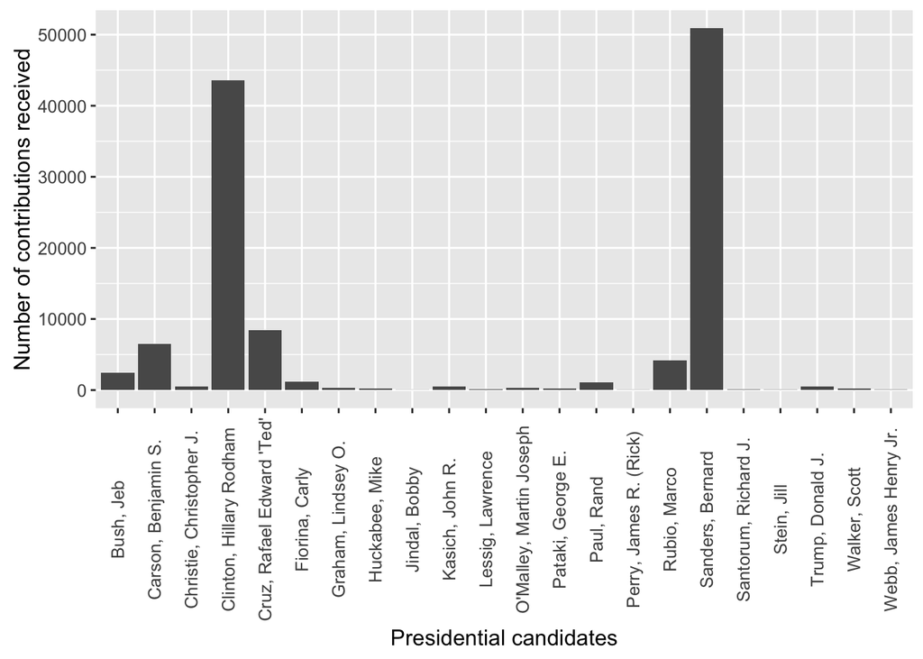

Clinton and Sanders have received the greatest number of individual contributions. Sanders has over 50,000 contributions and Clinton almost 45,000. Carson and Cruz have received between 5,000 and 10,000. All other candidates have received less than 5,000 each.

##### Cities

**Which cities in the State of New York made the greatest number of contributions?**

```r
head(summary(contribution_data$contbr_city))
```

```
##      NEW YORK      BROOKLYN         BRONX     ROCHESTER       BUFFALO
##         38229         13740          2122          1799          1574
## STATEN ISLAND
##          1295
```

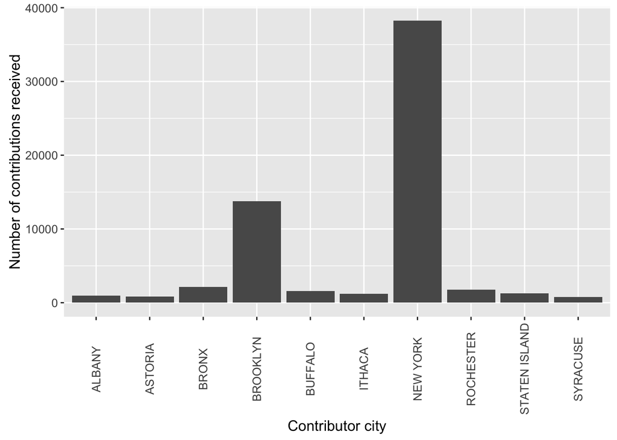

New York City leads in number of individual contributions with 38,229. A quick look at the data suggests that the actual value is likely to be larger, as Brooklyn, The Bronx and Staten Island - reported separately in the dataset - are New York City boroughs.

##### Occupations

**What are the occupations who have made the greatest number of contributions?**

The supporters in the State of New York who have made the greatest number of campaign contributions are those retired, with over 15,000 contributions and not employed, with over 12,500 contributions.

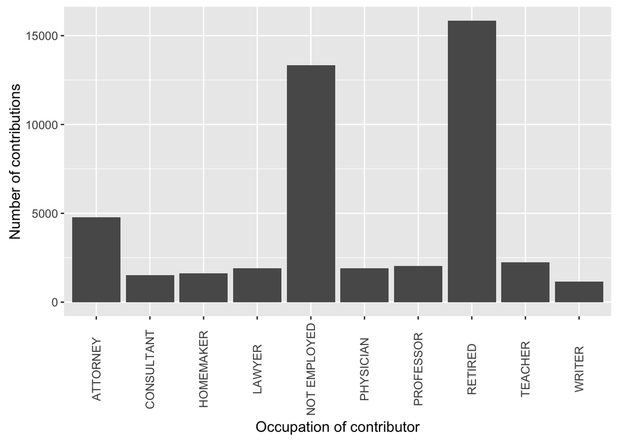

I replotted the top 10 occupations after excluding individuals who are retired and not employed. In the new top 10, supporters who are in legal professions (attorneys and lawyers) and teachers or professors have made the largest number of contributions.

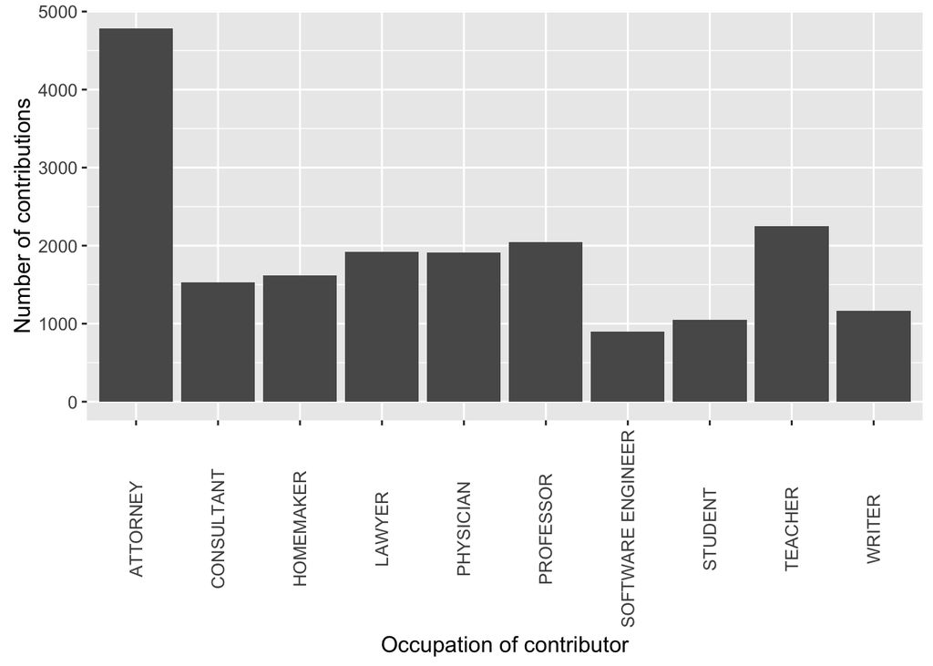

**Who are the top 10 employers by number of contributions of their employees?**

The top 10 employers of contributors are Clinton’s campaign “Hillary for America”, universities (City University, Cornell, Columbia, NYU), the public sector (City of New York, New York State, NYC Department of Education), Google and Goldman Sachs.

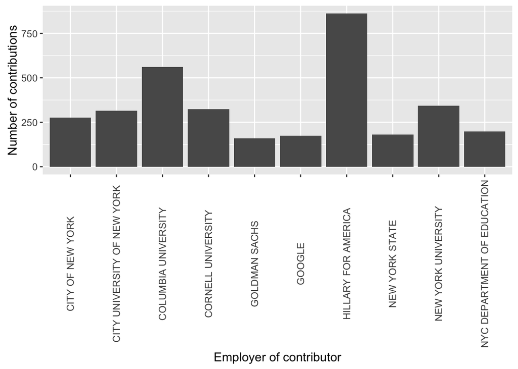

##### Contribution amount

**How can all the available contribution amount data be described?**

Summary statistics of the complete set of 121,529 observations show:

- Prevalence of contributions of small value (median of USD 50 and USD 116 as 3rd Quartile);
- Mean contribution amount (US$365) higher than 3rd Quartile, suggesting long tail of values;
- A maximum value of USD 3,686,000, confirming the existence of outliers;
- Presence of negative values (probably refunds), e.g. the minimum of USD -5,400.

```r
summary(contribution_data$contb_receipt_amt)
```

```
##    Min. 1st Qu.  Median    Mean 3rd Qu.    Max.
##   -5400      25      50     365     116 3686000
```

I visualize this data through a density plot, applying a log10 transformation to positive `contb_receipt_amt` values on the x axis and a sqrt transformation to density on the y-axis. The plot resembles a normal distribution with a long tail including values around 1e+06 (i.e. >USD 1m).

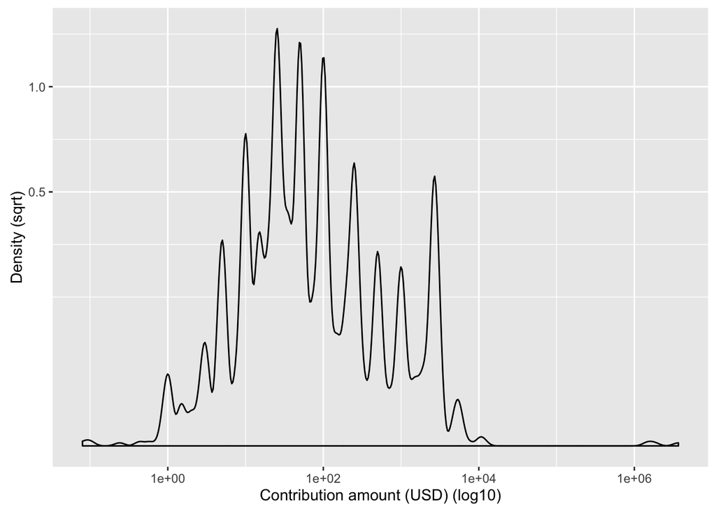

##### Contribution dates

**What is the number of contributions over time?**

In order to analyse and visualize contribution dates, I convert date values in the dataset from string (e.g. “29-FEB-16”) to Date format (e.g. 2016-02-29) and select observations with positive contribution amounts and non-NA date values.

The filtered dataset contains 120,068 observations with contribution dates ranging from 11 October 2013 and 29 February 2016.

```r
summary(selected_dates$contb_receipt_dt)
```

```
##         Min.      1st Qu.       Median         Mean      3rd Qu.
## "2013-10-11" "2015-10-16" "2016-01-12" "2015-12-06" "2016-02-11"
##         Max.
## "2016-02-29"
```

The frequency plot below shows how the number of individual contributions has grown over time. Exponential growth in number of contributions started around April 2015. Quartile statistics and the plot show that 75% of all contributions were received starting October 2015 and more than half starting January 2016.

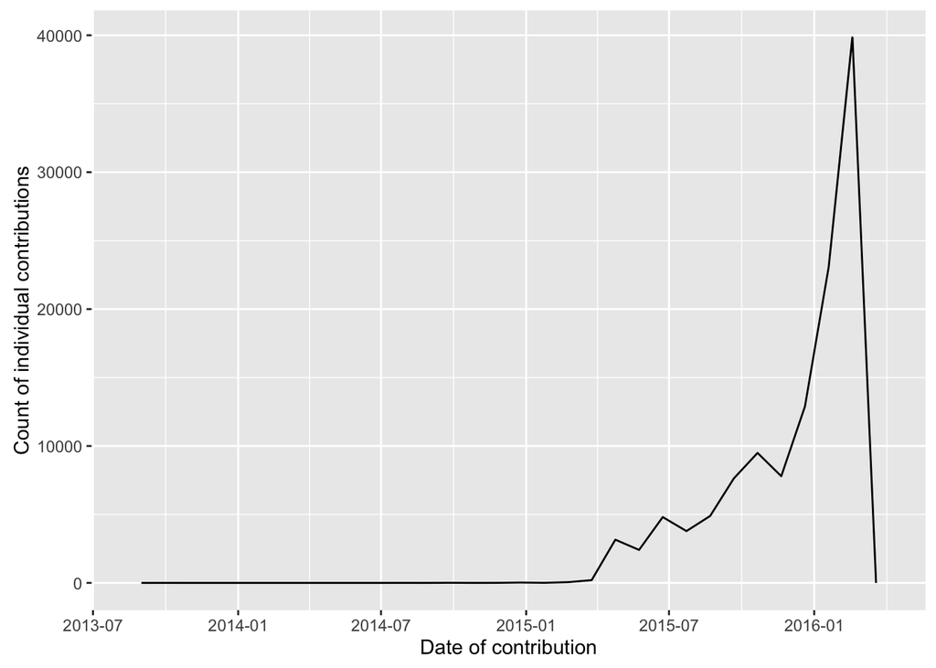

#### 4. Explore relationships between variables

In this section I explore relationships between different variables.

##### Data wrangling

Before doing further analysis, I select the observations that meet the following criteria:

- Non-negative contribution amount;
- Max contribution amount of USD 2,700;
- Non-NA contribution date value.

According to [US Federal Election Commission rules](http://www.fec.gov/info/contriblimitschart1516.pdf) , USD 2,700 is the contribution limit for individuals’ donations to candidates.

```r
# Select based on criteria
select_data = filter(contribution_data,
                     contb_receipt_amt > 0 & contb_receipt_amt <= 2700 &
                     !is.na(contb_receipt_dt))
# Convert dates from strings to the Date datatype
select_data$contb_receipt_dt = as.Date(select_data$contb_receipt_dt, "%d-%b-%y")
```

##### Contributions in the filtered dataset

**How can the contribution amount data in the filtered dataset be described?**

The new data frame `select_data` has 119,785 observations.

```r
length(select_data$contb_receipt_amt)
```

```
## [1] 119785
```

The total value of reported contributions in the period October 2013 - February 2016 is USD 35,911,638.

```r
sum(select_data$contb_receipt_amt)
```

```
## [1] 35911638
```

The majority of contributions is in small amounts. The median is USD 50 and the 3rd Quartile USD 121.90 over the entire period considered.

```r
summary(select_data$contb_receipt_amt)
```

```
##    Min. 1st Qu.  Median    Mean 3rd Qu.    Max.
##    0.08   25.00   50.00  299.80  121.90 2700.00
```

As the plot shows, in the 4th Quartile there are certain common donation amounts: USD 250, 500, 1,000 and 2,700 (the maximum allowed).

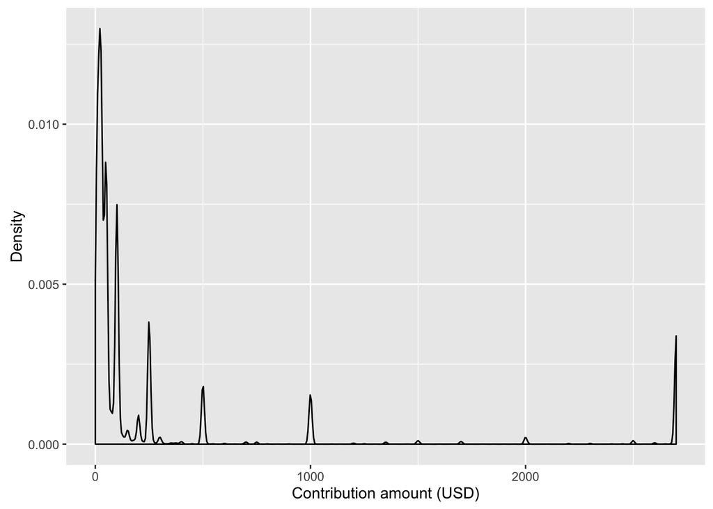

##### Value of contributions over time

**What is the value of contributions over time?**

Most of the donations from within the State of New York were made after April 2015, which is the month both Clinton and Sanders formally [announced their candidacy](https://en.wikipedia.org/wiki/United_States_presidential_election,_2016_timeline#April).

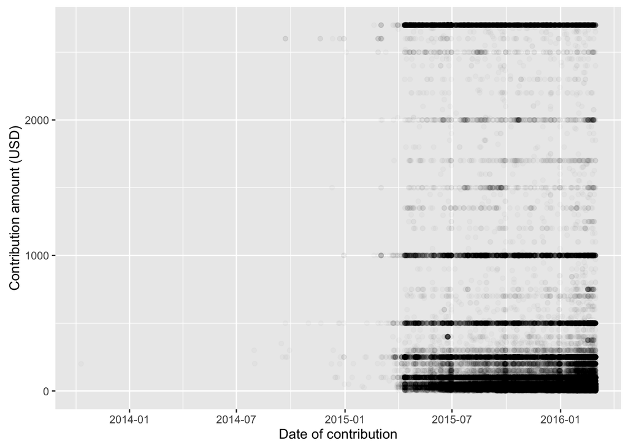

To understand the actual monetary value of the donations over time, I plot a graph with mean donation values by date.

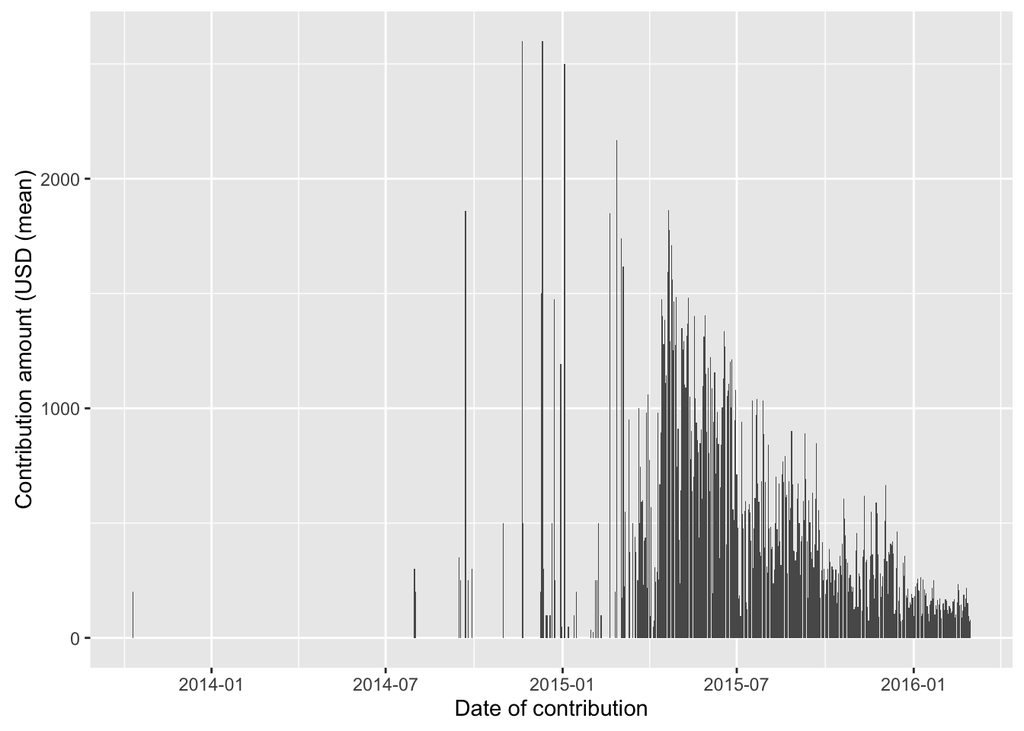

##### Value of contributions by city

**What is the total value of contributions for the top 10 cities?**

I explore the value of contributions by city by plotting the total value (sum of `contb_receipt_amt`) of individual contributions for the top 10 cities by number of contributions.

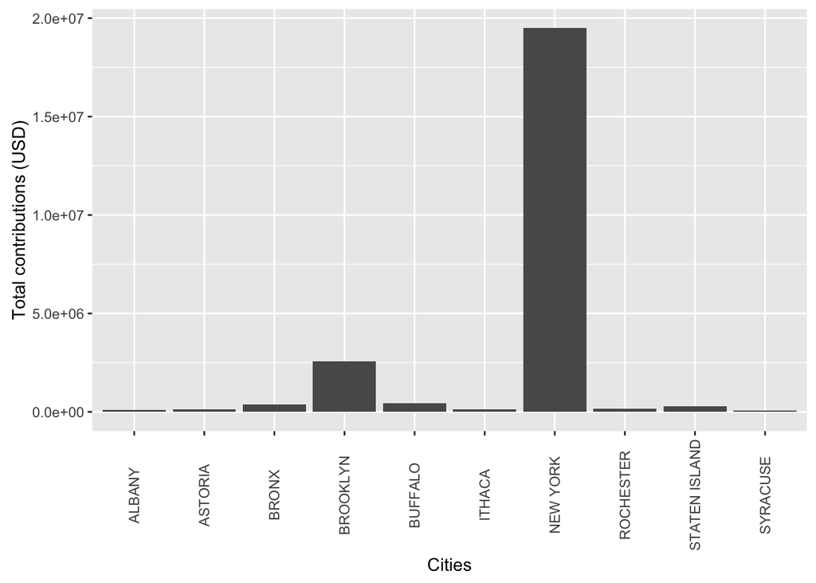

New York City contributed almost USD 20 million of the total USD 35,911,63 in the filtered dataset. Another USD 2.5 million were contributes by supporters in Brooklyn, also part of New York City.

##### Number of contributions by candidate

For this exploration, I select the candidates who are still running active campaigns: Clinton, Cruz, Kasich, Sanders and Trump.

```r
selected_candidates = filter(select_data,
                        cand_nm == "Clinton, Hillary Rodham" |
                                cand_nm == "Cruz, Rafael Edward 'Ted'" |
                                cand_nm == "Kasich, John R." |
                                cand_nm == "Sanders, Bernard" |
                                cand_nm == "Trump, Donald J.")
```

**How many contributions has each candidate received in the period?**

This bar chart is a subset of the first graph

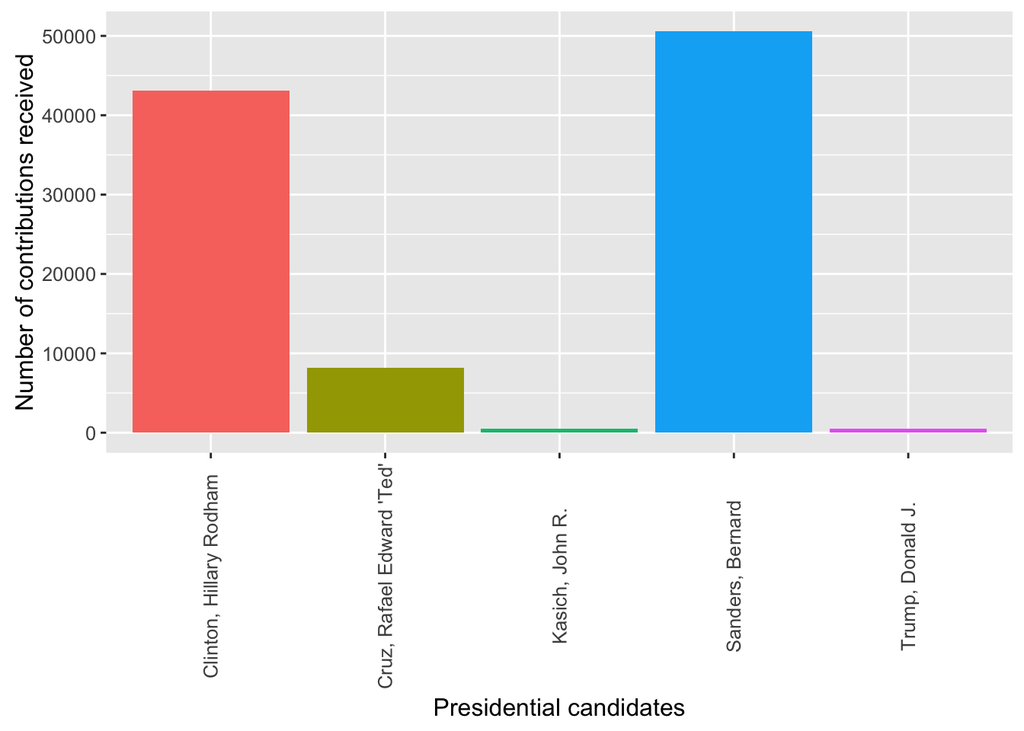

**How is number of contributions distributed over the period for each candidate?**

I use a density diagram to see how each candidate’s total contributions are distributed over the period.

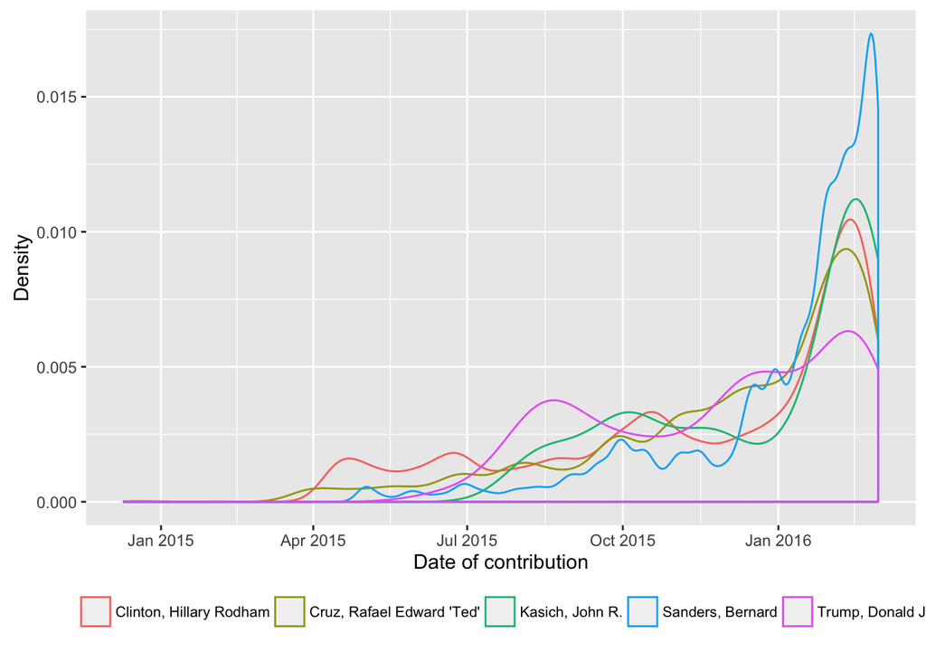

##### Value of contributions by candidate

**What is the value of the contributions received by each candidate?**

The mean value of contributions received by candidates in the overall period is plotted below. Kasich, who had one of the smallest numbers of contributions, has the highest mean value of almost USD 1,000. He is followed by Clinton with an average contribution value of almost USD 500. Sanders has the smallest mean value of contributions, less than USD 100.

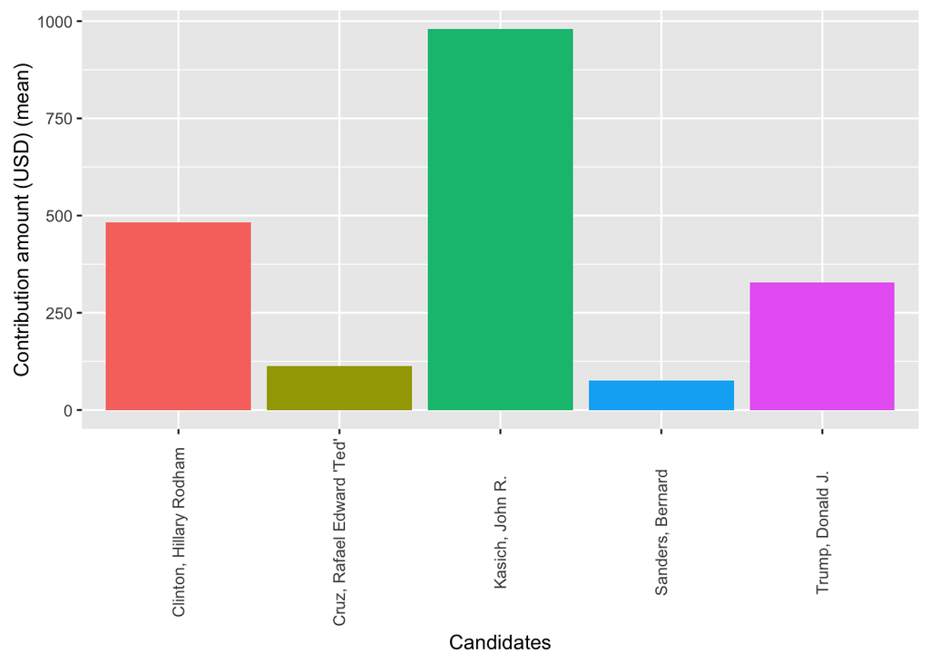

I then use boxplots to explore the distribution of the value of contribution received by each candidate.

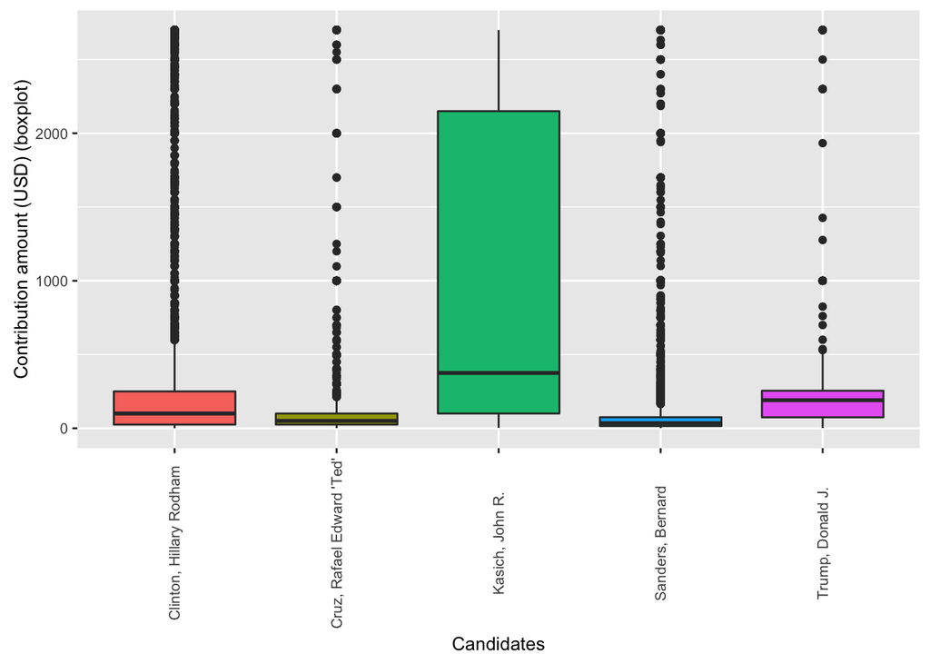

The boxplots show that most of the contributions have small median value and are concentrated around the median for Clinton, Cruz, Sanders and Trump. While having received few contributions, Kasich has the highest value median contribution.

##### Contributions by occupation

**What is the value of the contributions made by occupation?**

In order to explore the value of contributions by occupation I plot their mean values.

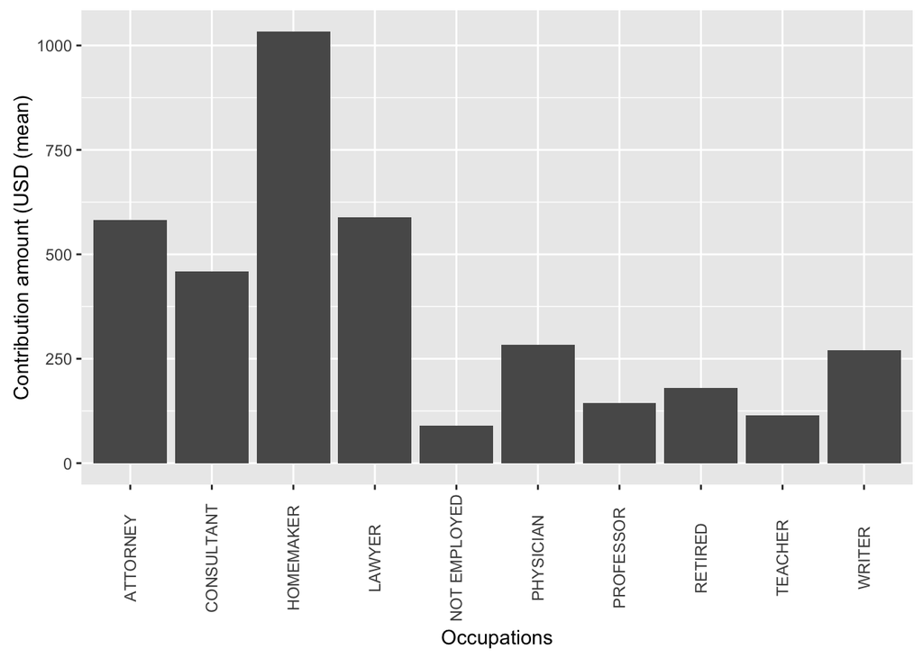

Homemakers have the highest mean contribution value of USD 1,000, followed by lawyers and attorneys each with mean contributions of over USD 500, and consultants with mean contribution just below USD 500.

Boxplots then allow us to explore the distribution of contribution value by occupation.

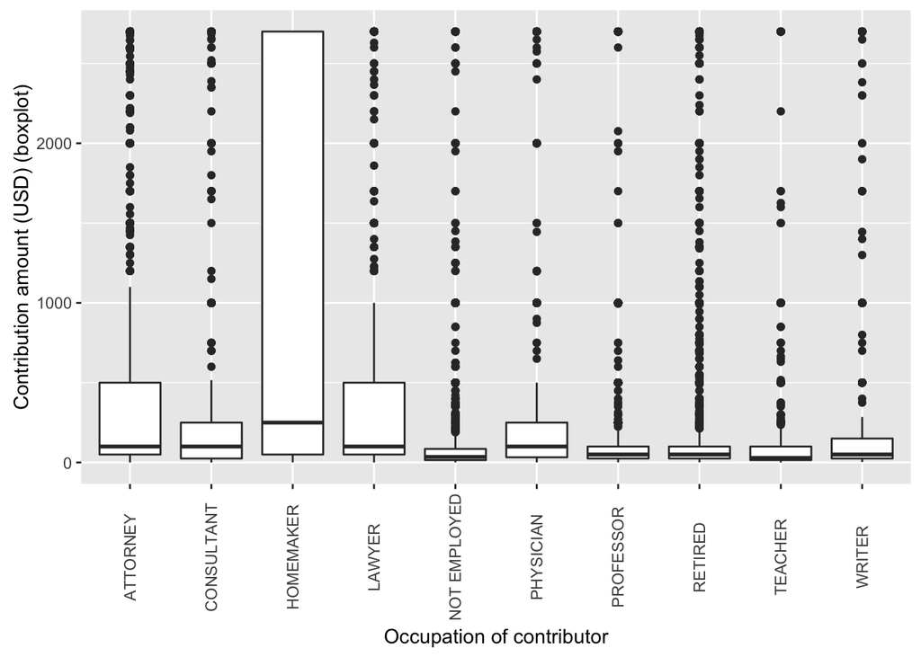

Housemakers also have the highest median contribution.

#### 5. Final plots and summary

In this section I present three of the plots explored in the previous section with some additional comments.

##### 1. Trend in value of contributions

**As the number of contributions grows, their mean value is declining**

One of the research questions in the exploration was about how value of contributions changed over time. To answer it, I plotted a bar chart with mean contributon amount for each day of the campaign, and a smoothed conditional mean line to highlight the trend.

I discovered that, while the number of contributions per day has grown since April 2015, their mean value has been steadily declining. A possible explanation is that contributions of smaller amount have grown faster than the others.

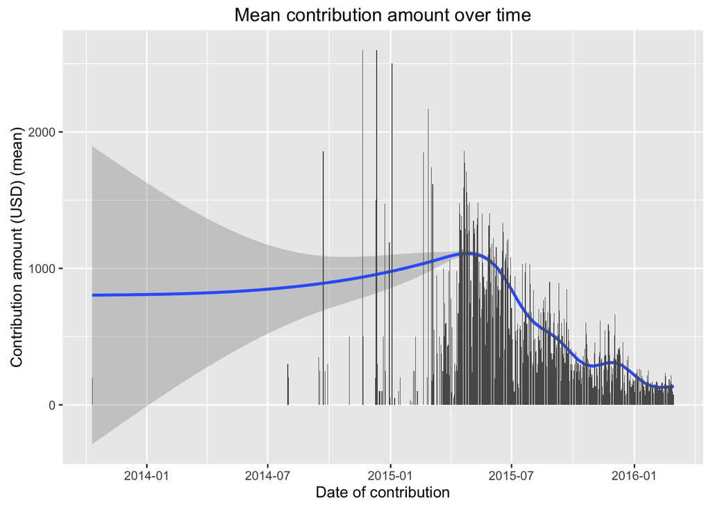

##### 2. Popularity of candidates

**All candidates have higher density of contributions between December 2015 and February 2016**

Another key question was about how the number of contributions has varied over time for each candidate. I used density plots to visualize how the number of contributions is distributed over time, independently of their absolute value.

For all five selected candidates the density of contributions has risen since December 2015. Sanders has a higher proporion of contributions made to him between January and February 2016 than any other candidate.

Could this mean that the popularity of Sanders has grown faster than other candidates’ in the period? Further investigation would be required to establish how this phenomenon is significantly related to popularity.

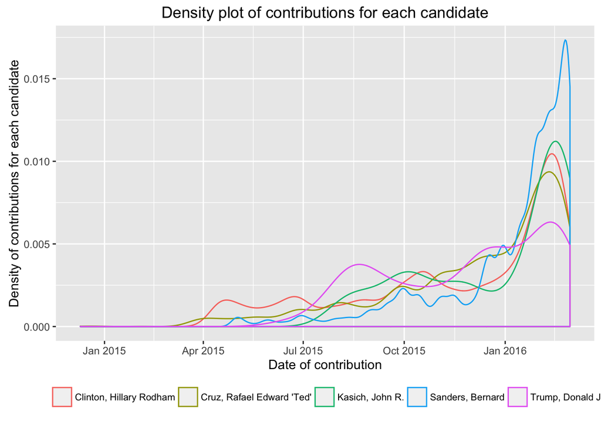

##### 3. The greatest contributors

**Housemakers have the highest mean and median contribution values**

A third question in the exploration was about how the value of contributions made is related to the occupation of supporters. I visualized this through boxplots and mean contribution value for the top 10 occupations by number of contributions. Mean in blue and outliers in red.

Housemaker supporters have the highest median and mean contribution value of all occupations in the top 10. All other professions also have smaller variance, and mean values beyond the 3rd Quartile, as a result of outlier contribution values up to the maximum of USD 2,700.

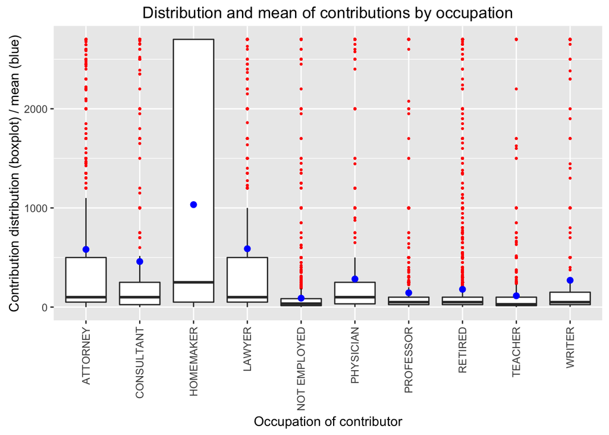

#### 6. Reflection

**Summary of the exploration process**

I decided to explore a dataset of financial contribution to 2016 US presidential candidates made available by the US Federal Election Commission. I selected the available data for the State of New York.

After loading an exploring the structure of the dataset in RStudio, I performed univariate exploration of selected variables, followed by exploration between selected variables.

In particular, I focused on:

- Number and value of the contributions;
- How number and value vary over time;
- The five candidates with active campaigns as of April 2016;
- Top 10 contributor occupations by number of contributions made;
- Top 10 cities by number of contributions made.

I then selected three plots and provided additional comments.

**Important choices made**

**Challenges**

The single greatest challenge in this data exploration has been working with a large number of categorical variables, and only contribution value as a numerical variable.

**Ideas for future research**

Ideas for future research could be:

- Extending the analysis to include multiple US states;
- Exploring the data about candidates who no longer have active campaigns, for comparison.